# Explore and summarize data (Red wine quality) by Edgar Eguia

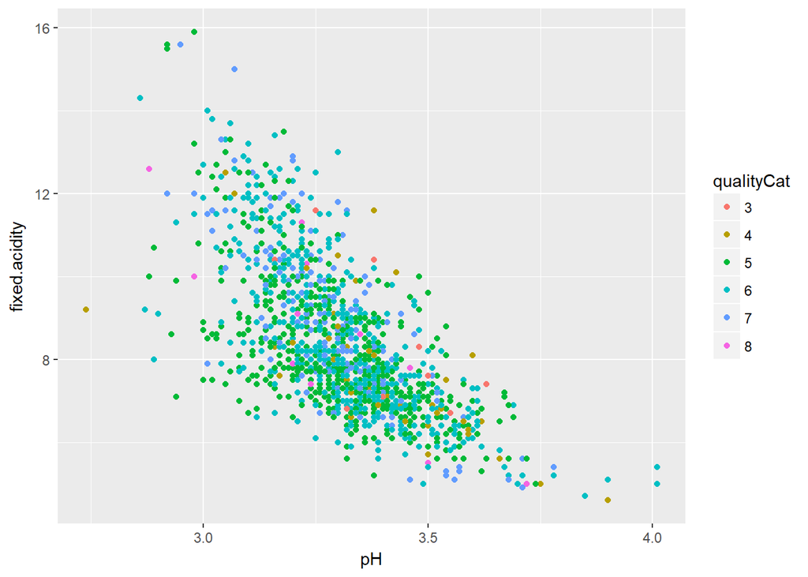

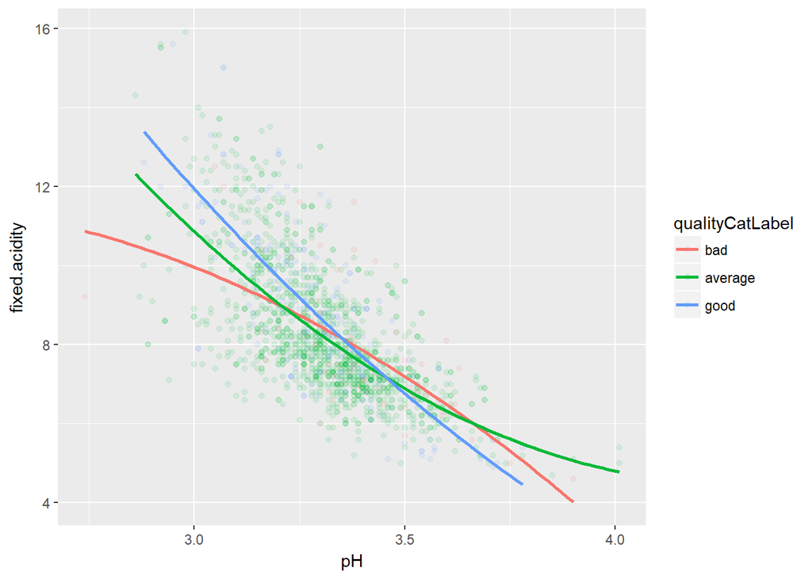

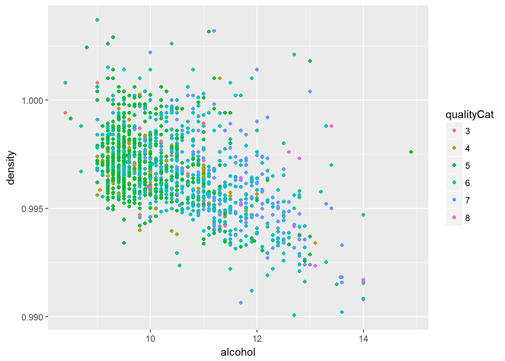

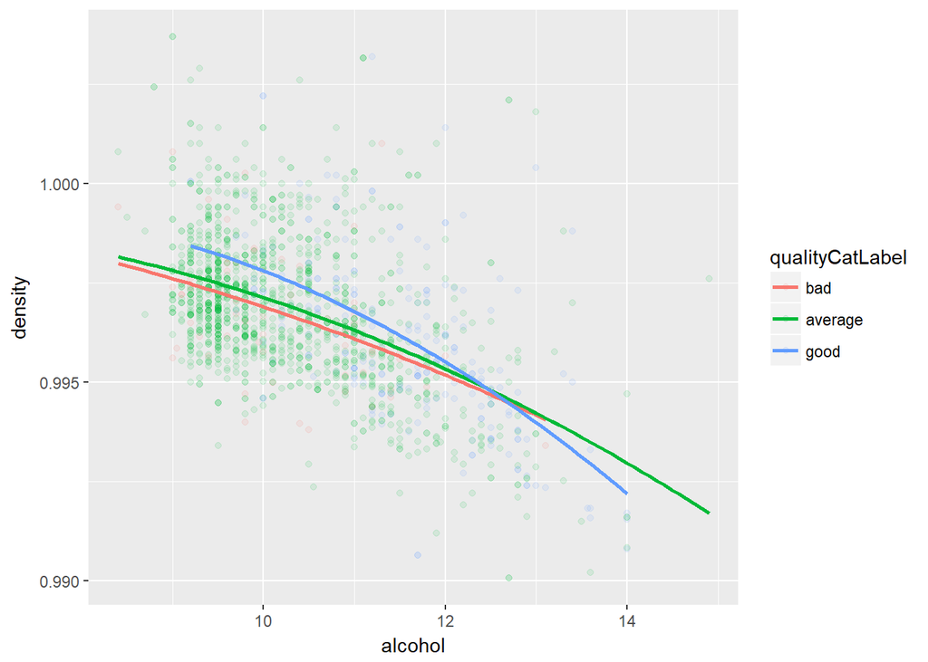

# Multivariate Analysis

### Talk about some of the relationships you observed in this part of the investigation. Were there features that strengthened each other in terms of looking at your feature(s) of interest?

**I got 3 interesting scatterplots related to quality (fixed acidity vs citric acid, fixed acidity vs pH and density vs alcohol), they are interesting because at low x values it seems that good quality wines have higher or lower y values than average and bad quality wines, but then when x value reaches certain point average and bad quality wines have higher or lower y values than good quality wines. It can be observed that there are thresholds when talking about features involved in the plots mentioned.**

### Were there any interesting or surprising interactions between features?

**As I mentioned before surprising interactions are the ones that reveals thresholds because I would have expected no changes among behaviour of fitted lines plotted in scatterplots.**

# Final Plots and Summary

### Plot One

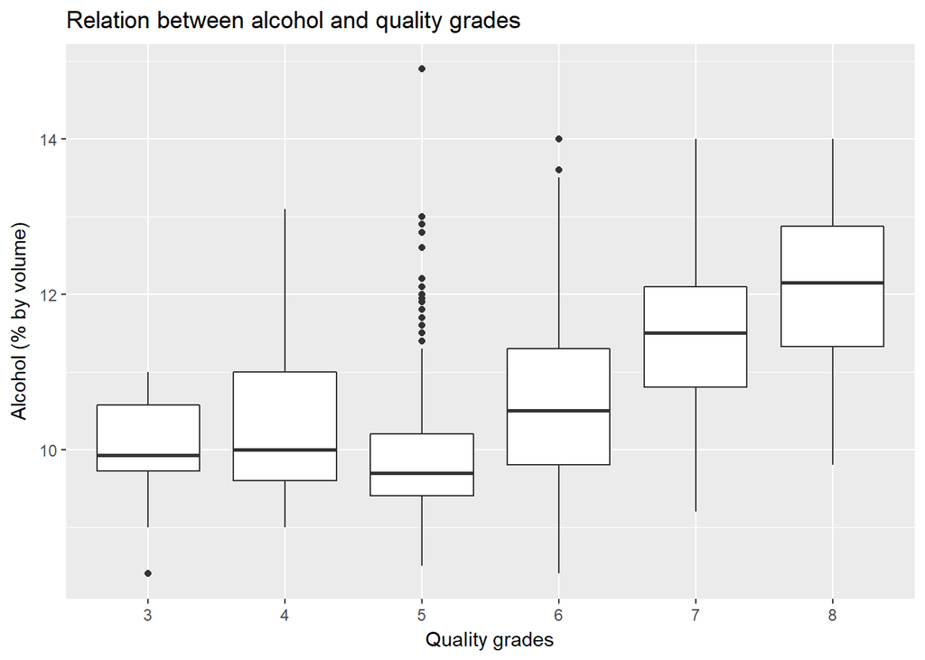

### Description One

**Box plot (alcohol vs quality). Trend shows that as quality value increases alcohol median value also increases (this only happens for qualities 5 to 8). Qualities 3 to 4 show approximately a constant trend. Correlation among these variables is positive (0.5 / according to correlation matrix). Highest correlation coefficient for quality against any variable. This implies to me that alcohol is closely related to wines quality. See reflection section.**

### Plot Two

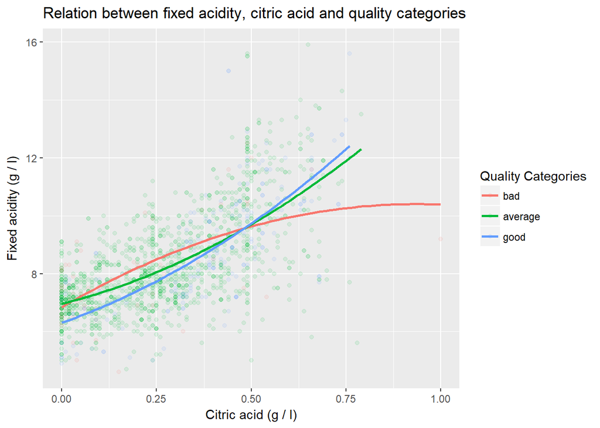

### Description Two

**Scatter plot (fixed acidity vs citric acid). Trend shows that as citric acid value increases fixed acidity value also increases. Qualities have been grouped in bad, average and good. Second degree polynomial fitting is used to reveal trends per quality groups. I can observe that good quality wines have lower levels of fixed acidity than average and bad quality wines considering same citric acid levels when citric acid level is below 0.50, above this level good quality wines have higher levels of fixed acidity than average and bad quality wines considering same citric acid levels. Points in scatterplot have been faded away to improve visualization. There is an interesting behaviour among qualities, behaviour is dependant on threshold in citric acid or fixed acidity, it depends the way we see the plot, the important thing is to notice that despite the fact that correlation coefficients among quality and variables are not high or low enoguh it seems that there is some kind of hidden important relation here. See reflection section.**

### Plot Three

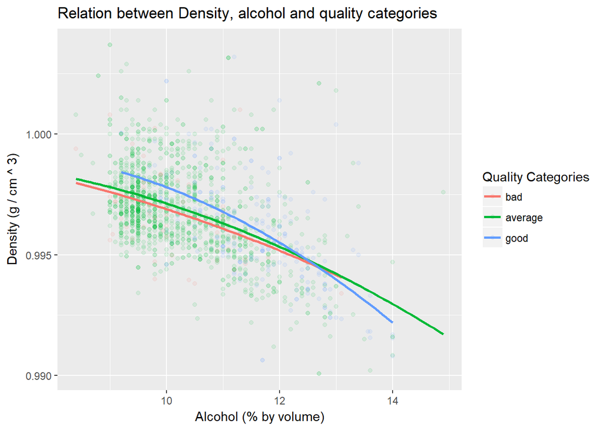

### Reflection

**EDA has been performed by looking at variables/features behaviour in univariate, bivariate and multivariate plots/summaries. These plots/summaries are tools to discover important relations among variables. The main interest of this exploration is to get to know what variables/features impact red wines quality.**

**Interesting relations came up, like the one between alcohol and quality grades. According to this relation If I have to choose among red wine bottles I should look for the one with highest alcohol level (% by volume) because this one will be the one with the highest quality.**

**Investigations across internet showed me that fixed acidity and citric acid are closely related, in fact; citric acid is a fixed acid (the other ones being tartaric, malic and succinic) so it´s natural that as citric acid increases, fixed acidity also increases. According to this relation If I have to choose among red wine bottles considering wines with less than 0.50 citric acid (g/l or its equivalent in other units) I should look for the one with the lowest fixed acidity, and above 0.50 citric acid (g/l or its equivalent in other units) the one with the highest fixed acidity. These ones will be the ones with the highest quality.**

**Investigations across internet showed me that density and alcohol are closely related. During alcohol fermentation, yeast converts sugars into carbon dioxide and alcohol. The decline in the sugar content and the presence of ethanol (alcohol which is appreciably less dense than water) drop the density of the wort (decreasing overall density). According to this relation if I have to choose among red wine bottles considering wines with less than 12.5 alcohol level (% by volume) I should look for the one with the highest density, and above 12.5 alcohol level (% by volume) the one with lowest density. These ones will be the ones with the highest quality.**

**Evaluating wines is a complex skill and it´s subjective (depends on sommelier). I can see that highest (0.7) or lowest (-0.7) correlation coefficients values were obtained among variables/features that by nature (chemical properties) are highly related. If we were talking about something different than wines we would expect these coefficients to behave similar (this is the case for fixed acidity vs citric acid). The variables/features that impact quality are not really identified because low values above 0 and high values below 0 are obtained in correlation matrix so these values are not helping me to identify important relations. I´m not expert about wines but I guess dataset needs more variables/features to discover the ones that really impact wines quality.**

### References on the internet

*http://waterhouse.ucdavis.edu/whats-in-wine/fixed-acidity, https://en.wikipedia.org/wiki/Wort*